# R-2022 egzamino sprendimai

Penktadienio grupė

2023-01-12 13:56:14

Atlikę visas užduotis ir pavertę ataskaitą į HTML, projektą suarchyvuokite ZIP formatu ir įkelkite į „Emokymai“. Projekto aplanko ir bylų pervadinti **nereikia** (t.y., palikite pavadinimus tokius, kokie yra).

Šį dokumentą į HTML paverskite bent 2 kartus. Geriausia, kad `knit` mygtuką spaustumėte reguliariai.

Atlikę kiekvieną užduotį, pakeitimus išsaugokite naudodami *Git*.

Techniniai reikalavimai visoms užduotims:

1. Visi paketai ir pagrindiniai nustatymai atliekami `setup` bloke.
2. Visi `ggplot2` pagrindu sukurti grafikai turi naudoti tą pačią temą, kuri turi būti kitokia, nei numatytoji `ggplot2` tema.
3. Nekeiskite dokumento struktūros: nepridėkite papildomų skyrių.

```r
# Paketai ir funkcijos
library(tidyverse)
library(factoextra)
library(DescTools)
library(data.table)
library(ggplot2)
library(ggstatsplot)
library(ggmosaic)
library(ggthemes)


# Nustatymai
knitr::opts_chunk$set(
  echo       = TRUE,
  eval       = TRUE,
  fig.height = 4,
  fig.width  = 6,
  fig.align  = "center"
)
options(
  styler.addins_style_transformer = "styler::tidyverse_style(strict = FALSE)"
)
```

```r
fs::dir_tree(recurse = TRUE)
```

```
## .
## ├── analize.html
## ├── analize.Rmd
## ├── duomenys
## │   ├── pingvinai-n.xlsx
## │   ├── sugertis-2.txt
## │   └── wine
## │       ├── winequality-red.csv
## │       ├── winequality-white.csv
## │       └── winequality.names
## ├── funkcijos
## │   ├── funkcijos--pi-skaiciavimui.R
## │   └── schema--pi-metodo-(ir-funkcijos)-pasirinkimas-(v1.1).pdf
## └── R-2022--E01--atsakymai.Rproj
```

# Užduotis 1

## Uždavinio sąlyga

Rekomenduojama sprendimo trukmė: 15-20 min.

1. Kolega jums davė šį projektą ir sakė, kad pirmos užduoties duomenys yra byloje `sugertis.txt`. Deja, jūs tų duomenų nerandate. Ar galėjo taip atsitikti, kad duomenys buvo (netyčia) ištrinti? Patikrinkite naudodami *Git* ir neatitikimą pašalinkite. T.y., sugrąžinkite prarastą bylą. Tam rekomenduojama naudoti *GitHub Desktop*.
2. Visus šio ir kitų uždavinių paketus užsikraukite `setup` bloke.
3. Įsikelkite duomenis.
4. Sudarykite tiesinės regresijos modelį (laikykite, kad visos modelio prielaidos yra tenkinamos: dėl riboto laiko jų netikrinsime).
5. Teisingai atvaizduokite ryšį tarp kintamųjų.
6. Regresijos rezultatus (lygtį ir t.t.) tinkamai aprašykite. Atsakymus apvalinkite korektiškai.

## Sprendimas

```r
sugertis1 <- read_csv(file = "duomenys/sugertis-2.txt")
sugertis2 <-
  sugertis1 %>%
  set_names(c("koncentracija", "sugertis"))

glimpse(sugertis2)
```

```
## Rows: 24
## Columns: 2
## $ koncentracija <dbl> 0.0, 0.0, 0.0, 0.0, 0.0, 0.0, 0.5, 0.5, 0.5, 0.5, 0.5, 0…
## $ sugertis      <dbl> 0.007377, 0.009247, 0.025861, 0.016247, 0.005684, 0.0078…
```

```r
summary(sugertis2)
```

```
##  koncentracija      sugertis
##  Min.   :0.000   Min.   :0.005684
##  1st Qu.:0.375   1st Qu.:0.010733
##  Median :0.750   Median :0.015388
##  Mean   :0.875   Mean   :0.014033
##  3rd Qu.:1.250   3rd Qu.:0.016418
##  Max.   :2.000   Max.   :0.025861
```

```r
modelis1 <- lm(sugertis ~ koncentracija, data = sugertis2)
```

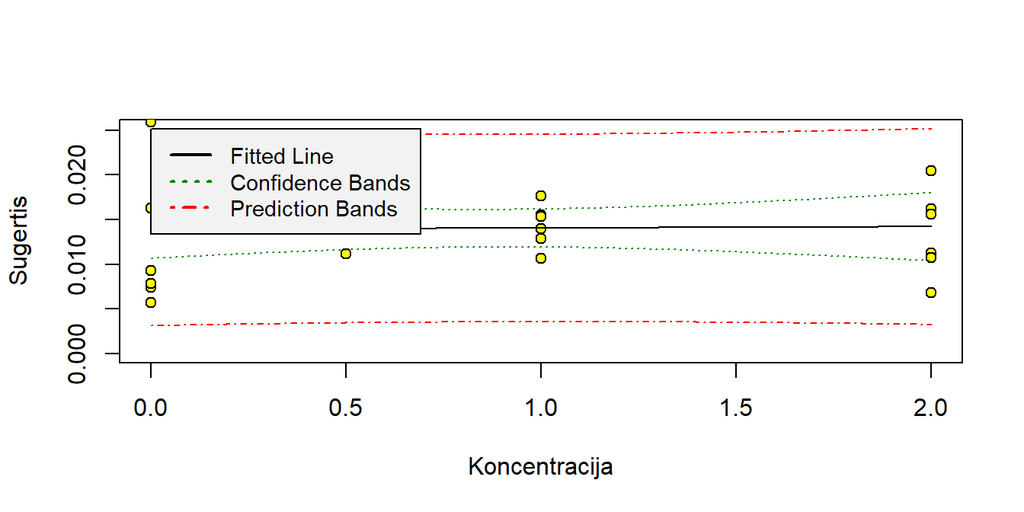

```r
chemCal::calplot(modelis1, xlab = "Koncentracija", ylab = "Sugertis")
```

```r
summary(modelis1)
```

```
##
## Call:
## lm(formula = sugertis ~ koncentracija, data = sugertis2)
##
## Residuals:
##       Min        1Q    Median        3Q       Max
## -0.008217 -0.003407  0.001294  0.002482  0.011960
##
## Coefficients:
##                Estimate Std. Error t value Pr(>|t|)
## (Intercept)   0.0139008  0.0015659   8.877 1.01e-08 ***
## koncentracija 0.0001506  0.0013668   0.110    0.913
## ---
## Signif. codes:  0 '***' 0.001 '**' 0.01 '*' 0.05 '.' 0.1 ' ' 1
##
## Residual standard error: 0.004952 on 22 degrees of freedom
## Multiple R-squared:  0.0005513,  Adjusted R-squared:  -0.04488
## F-statistic: 0.01213 on 1 and 22 DF,  p-value: 0.9133
```

```r
nauja_reiksme1 <- 0.017

rez <- chemCal::inverse.predict(modelis1, newdata = nauja_reiksme1)

rez %>% map(scales::number, accuracy = 0.1) %>% unlist() %>% t() %>% as_tibble()
```

| Prediction | Standard Error | Confidence | Confidence Limits1 | Confidence Limits2 |
| --- | --- | --- | --- | --- |
| 20.6 | 182.0 | 377.5 | -356.9 | 398.1 |

# Atsakymas

# Užduotis 2

Rekomenduojama sprendimo trukmė: 50-80 min.

## Duomenų apibūdinimas

Duota raudonojo ir baltojo portugališko “Vinho Verde” vyno mėginių imtis.

**Kintamųjų apibūdinimas**

Kintamųjų apibūdinimas anglų kalba.

Variables based on physicochemical tests:

1. **fixed acidity** ($\frac{g_{\textrm{ (tartaric acid)}}}{l}$): most acids involved with wine or fixed or nonvolatile (do not evaporate readily).
2. **volatile acidity** ($g_{\textrm{ (acetic acid)}}/l$): the amount of acetic acid in wine, which at too high of levels can lead to an unpleasant, vinegar taste
3. **citric acid** ($g/l$): found in small quantities, citric acid can add ‘freshness’ and flavor to wines.
4. **residual sugar** ($g/l$): the amount of sugar remaining after fermentation stops, it’s rare to find wines with less than 1 gram/liter and wines with greater than 45 grams/liter are considered sweet.
5. **chlorides** ($g_{\textrm{ (sodium chloride)}}/l$): the amount of salt in the wine.
6. **free sulfur dioxide** ($mg/l$): the free form of SO₂ exists in equilibrium between molecular SO₂ (as a dissolved gas) and bisulfite ion; it prevents microbial growth and the oxidation of wine.
7. **total sulfur dioxide** ($mg/l$): amount of free and bound forms of SO₂; in low concentrations, SO₂ is mostly undetectable in wine, but at free SO₂ concentrations over 50 ppm, SO₂ becomes evident in the nose and taste of wine.
8. **density** ($g/cm^3$): the density of water is close to that of water depending on the percent alcohol and sugar content.
9. **pH**: describes how acidic or basic a wine is on a scale from 0 (very acidic) to 14 (very basic); most wines are between 3-4 on the pH scale.
10. **sulphates**: a wine additive which can contribute to sulfur dioxide gas (SO₂) levels, which acts as an antimicrobial and antioxidant
11. **alcohol** (% vol.): the percent alcohol content of the wine.

Variable based on sensory data:

12. **quality** (score between 0 and 10).

Tikslesnis duomenų aprašas, autoystė ir kilmė plačiau parašyta vyno duomenų aplanke esančioje informacinėje byloje. Tačiau taupant laiką jos skaityti nebūtina: esminė šiam atsiskaitymui informacija pateikta šiame dokumente.

## Sprendimai (1 dalis)

### Įsikelkite ir peržiūrėkite duomenis

Raudonojo ir baltojo vyno duomenys pateikti atskirose bylose, kurių plėtinys yra CSV. Įsikelkite duomenis ir patikrinkite, ar jie įsikėlė teisingai. Duomenų lenteles pavadinkite `red_wine` ir `white_wine`.

```r
red_wine <- read.csv(file = "duomenys/wine/winequality-red.csv", sep = ";")
glimpse(red_wine)
```

```
## Rows: 1,599
## Columns: 12
## $ fixed.acidity        <dbl> 7.4, 7.8, 7.8, 11.2, 7.4, 7.4, 7.9, 7.3, 7.8, 7.5…
## $ volatile.acidity     <dbl> 0.700, 0.880, 0.760, 0.280, 0.700, 0.660, 0.600, …
## $ citric.acid          <dbl> 0.00, 0.00, 0.04, 0.56, 0.00, 0.00, 0.06, 0.00, 0…
## $ residual.sugar       <dbl> 1.9, 2.6, 2.3, 1.9, 1.9, 1.8, 1.6, 1.2, 2.0, 6.1,…
## $ chlorides            <dbl> 0.076, 0.098, 0.092, 0.075, 0.076, 0.075, 0.069, …
## $ free.sulfur.dioxide  <dbl> 11, 25, 15, 17, 11, 13, 15, 15, 9, 17, 15, 17, 16…
## $ total.sulfur.dioxide <dbl> 34, 67, 54, 60, 34, 40, 59, 21, 18, 102, 65, 102,…
## $ density              <dbl> 0.9978, 0.9968, 0.9970, 0.9980, 0.9978, 0.9978, 0…
## $ pH                   <dbl> 3.51, 3.20, 3.26, 3.16, 3.51, 3.51, 3.30, 3.39, 3…
## $ sulphates            <dbl> 0.56, 0.68, 0.65, 0.58, 0.56, 0.56, 0.46, 0.47, 0…
## $ alcohol              <dbl> 9.4, 9.8, 9.8, 9.8, 9.4, 9.4, 9.4, 10.0, 9.5, 10.…
## $ quality              <int> 5, 5, 5, 6, 5, 5, 5, 7, 7, 5, 5, 5, 5, 5, 5, 5, 7…
```

```r
white_wine <- read.csv(file = "duomenys/wine/winequality-white.csv", sep = ";")
glimpse(white_wine)
```

```
## Rows: 4,898
## Columns: 12
## $ fixed.acidity        <dbl> 7.0, 6.3, 8.1, 7.2, 7.2, 8.1, 6.2, 7.0, 6.3, 8.1,…
## $ volatile.acidity     <dbl> 0.27, 0.30, 0.28, 0.23, 0.23, 0.28, 0.32, 0.27, 0…
## $ citric.acid          <dbl> 0.36, 0.34, 0.40, 0.32, 0.32, 0.40, 0.16, 0.36, 0…
## $ residual.sugar       <dbl> 20.70, 1.60, 6.90, 8.50, 8.50, 6.90, 7.00, 20.70,…
## $ chlorides            <dbl> 0.045, 0.049, 0.050, 0.058, 0.058, 0.050, 0.045, …
## $ free.sulfur.dioxide  <dbl> 45, 14, 30, 47, 47, 30, 30, 45, 14, 28, 11, 17, 1…
## $ total.sulfur.dioxide <dbl> 170, 132, 97, 186, 186, 97, 136, 170, 132, 129, 6…
## $ density              <dbl> 1.0010, 0.9940, 0.9951, 0.9956, 0.9956, 0.9951, 0…
## $ pH                   <dbl> 3.00, 3.30, 3.26, 3.19, 3.19, 3.26, 3.18, 3.00, 3…
## $ sulphates            <dbl> 0.45, 0.49, 0.44, 0.40, 0.40, 0.44, 0.47, 0.45, 0…
## $ alcohol              <dbl> 8.8, 9.5, 10.1, 9.9, 9.9, 10.1, 9.6, 8.8, 9.5, 11…
## $ quality              <int> 6, 6, 6, 6, 6, 6, 6, 6, 6, 6, 5, 5, 5, 7, 5, 7, 6…
```

### Pertvarkykite duomenis

1. Sujunkite lenteles

```r
# Vyno tipų sujungimas į vieną lentelę
wine <-
  bind_rows("Red" = red_wine, "White" = white_wine, .id = "wine_type")

remove(red_wine, white_wine)
```

2. Sukurkite dar vieną kintamąjį su vyno kokybės grupėmis.

```r
# Sukuriamas kintamasis `quality_gr`
wine <-
  wine |>
  mutate(quality_gr = cut(
    quality,
    breaks = c(0, 4.5, 6.5, 10),
    labels = c("low", "medium", "high"),
    include.lowest = TRUE,
    ordered_result = TRUE
  ))
```

3. Jei reikia, atlikite kitus pertvarkymus.

Naudodami žemiau pateiktą kodą, sukurkite kintamąjį – vyno kokybės grupes (balai ir kokybės grupė):

- ≤ 4 – prasta,
- [5-6] – vidutinė,
- ≥ 7 – gera.

```r
wine <-
  wine |>
  mutate(quality_gr = cut(
    quality,
    breaks = c(0, 4.5, 6.5, 10),
    labels = c("low", "medium", "high"),
    include.lowest = TRUE,
    ordered_result = TRUE
  ))
```

Sudarykite porinę dažnių lentelę patikrinti, ar į grupes buvo suskirstyta taip, kaip tikitės.

```r
# Dažnių lentelė pasitikrinimui
wine %>% with(table(quality_gr))
```

```
## quality_gr
##    low medium   high
##    246   4974   1277
```

### Atlikite kintamųjų reikšmių peržiūrą (I)

Atlikite “greitą” kiekvieno lentelės kintamojo peržiūrą ir įvertinkite pasiskirstymą. Nustatykite, ar yra anomalijų, neatitikimų. Tam rekomenduoju naudoti funkciją `DescTools::Desc()`, jei suprantate jos rezultatus, arba bet kokį kitą jums suprantamą metodą.

```r
DescTools::Desc(wine, vetbose = 3)
```

```
## ------------------------------------------------------------------------------
## Describe wine (data.frame):
##
## data frame:  6497 obs. of  14 variables
##      6497 complete cases (100.0%)
##
##   Nr  ColName               Class            NAs  Levels
##   1   wine_type             character        .
##   2   fixed.acidity         numeric          .
##   3   volatile.acidity      numeric          .
##   4   citric.acid           numeric          .
##   5   residual.sugar        numeric          .
##   6   chlorides             numeric          .
##   7   free.sulfur.dioxide   numeric          .
##   8   total.sulfur.dioxide  numeric          .
##   9   density               numeric          .
##   10  pH                    numeric          .
##   11  sulphates             numeric          .
##   12  alcohol               numeric          .
##   13  quality               integer          .
##   14  quality_gr            ordered, factor  .    (3): 1-low, 2-medium,
##                                                   3-high
##
##
## ------------------------------------------------------------------------------
## 1 - wine_type (character - dichotomous)
##
##   length      n    NAs unique
##    6'497  6'497      0      2
##          100.0%   0.0%
##
##         freq   perc  lci.95  uci.95'
## White  4'898  75.4%   74.3%   76.4%
## Red    1'599  24.6%   23.6%   25.7%
##
## ' 95%-CI (Wilson)
```

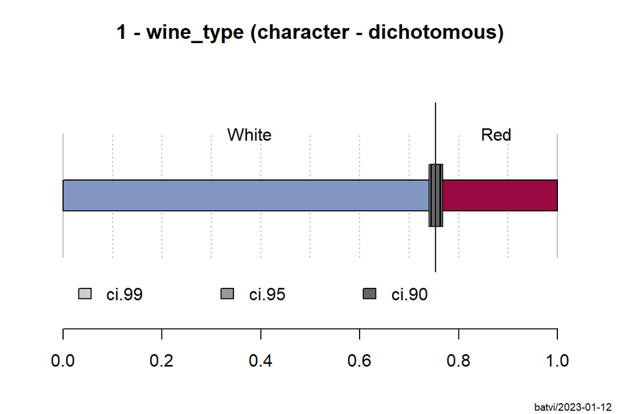

```
## ------------------------------------------------------------------------------
## 2 - fixed.acidity (numeric)
##
##   length       n    NAs  unique    0s  mean  meanCI'
##    6'497   6'497      0     106     0  7.22    7.18
##           100.0%   0.0%          0.0%          7.25
##
##      .05     .10    .25  median   .75   .90     .95
##     5.70    6.00   6.40    7.00  7.70  8.80    9.80
##
##    range      sd  vcoef     mad   IQR  skew    kurt
##    12.10    1.30   0.18    0.89  1.30  1.72    5.05
##
## lowest : 3.8, 3.9, 4.2 (2), 4.4 (3), 4.5
## highest: 14.3, 15.0 (2), 15.5 (2), 15.6 (2), 15.9
##
## ' 95%-CI (classic)
```

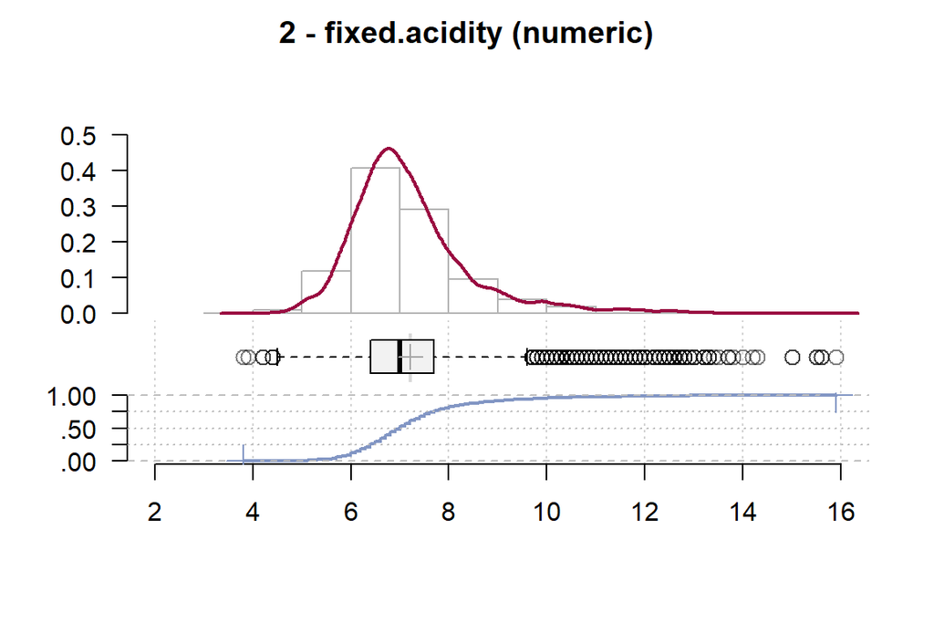

```
## ------------------------------------------------------------------------------
## 3 - volatile.acidity (numeric)
##
##   length       n    NAs  unique    0s  mean  meanCI'
##    6'497   6'497      0     187     0  0.34    0.34
##           100.0%   0.0%          0.0%          0.34
##
##      .05     .10    .25  median   .75   .90     .95
##     0.16    0.18   0.23    0.29  0.40  0.59    0.67
##
##    range      sd  vcoef     mad   IQR  skew    kurt
##     1.50    0.16   0.48    0.12  0.17  1.49    2.82
##
## lowest : 0.08 (4), 0.08, 0.09, 0.1 (6), 0.1 (6)
## highest: 1.18, 1.18, 1.24, 1.33 (2), 1.58
##
## ' 95%-CI (classic)
```

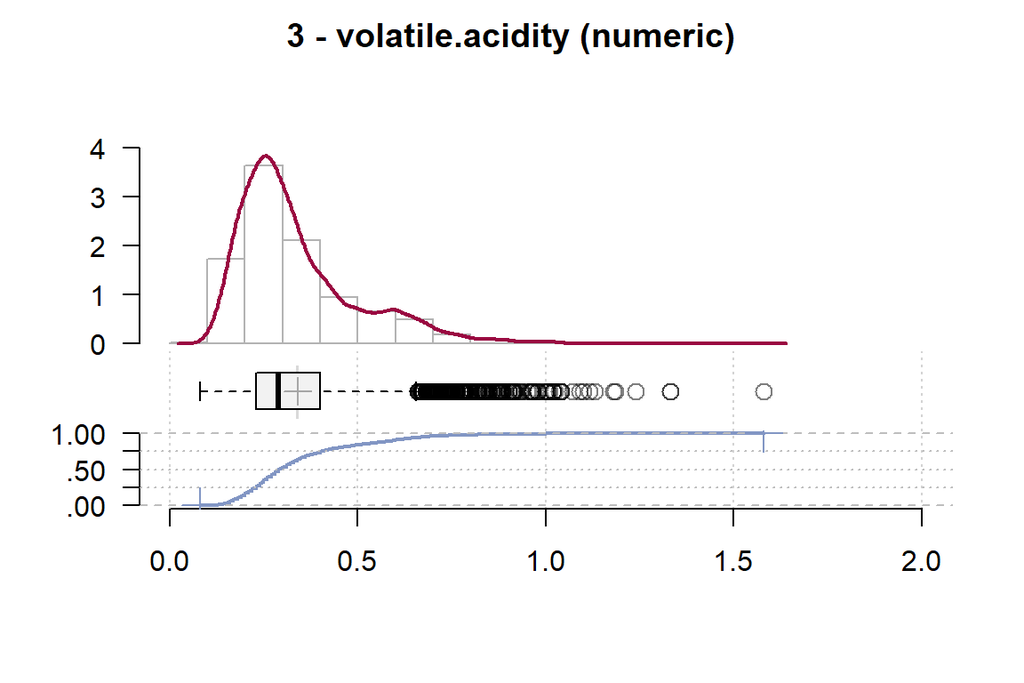

```
## ------------------------------------------------------------------------------
## 4 - citric.acid (numeric)
##
##   length       n    NAs  unique    0s  mean  meanCI'
##    6'497   6'497      0      89   151  0.32    0.32
##           100.0%   0.0%          2.3%          0.32
##
##      .05     .10    .25  median   .75   .90     .95
##     0.05    0.14   0.25    0.31  0.39  0.49    0.56
##
##    range      sd  vcoef     mad   IQR  skew    kurt
##     1.66    0.15   0.46    0.10  0.14  0.47    2.39
##
## lowest : 0.0 (151), 0.01 (40), 0.02 (56), 0.03 (32), 0.04 (41)
## highest: 0.91 (2), 0.99, 1.0 (6), 1.23, 1.66
##
## ' 95%-CI (classic)
```

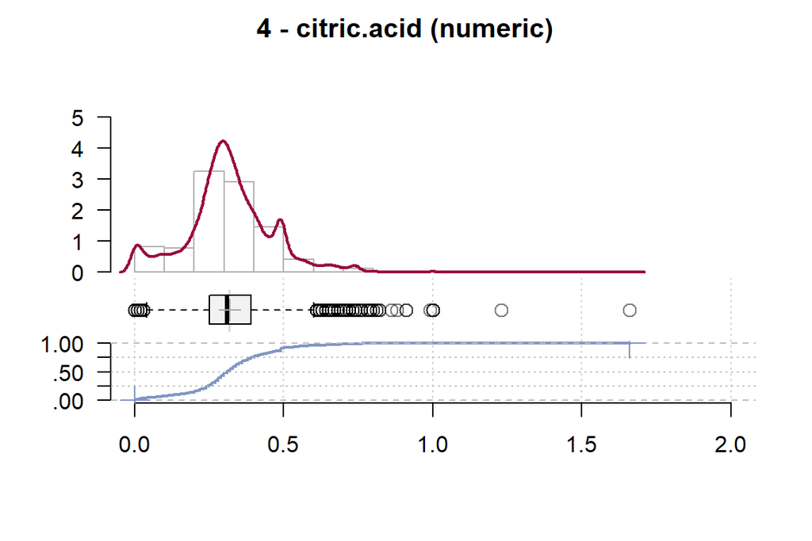

```
## ------------------------------------------------------------------------------
## 5 - residual.sugar (numeric)
##
##   length       n    NAs  unique    0s   mean  meanCI'
##    6'497   6'497      0     316     0   5.44    5.33
##           100.0%   0.0%          0.0%           5.56
##
##      .05     .10    .25  median   .75    .90     .95
##     1.20    1.30   1.80    3.00  8.10  13.00   15.00
##
##    range      sd  vcoef     mad   IQR   skew    kurt
##    65.20    4.76   0.87    2.52  6.30   1.43    4.35
##
## lowest : 0.6 (2), 0.7 (7), 0.8 (25), 0.9 (41), 0.95 (4)
## highest: 22.6, 23.5, 26.05 (2), 31.6 (2), 65.8
##
## ' 95%-CI (classic)
```

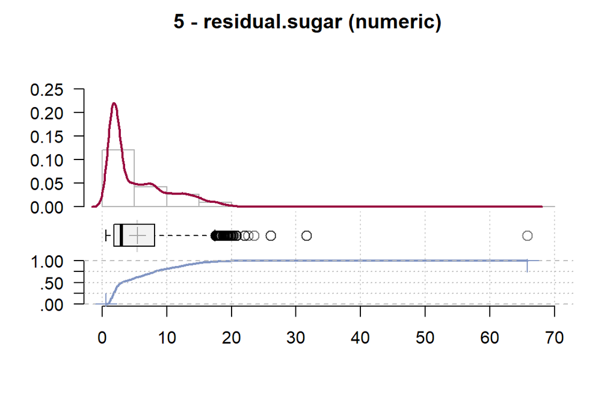

```
## ------------------------------------------------------------------------------
## 6 - chlorides (numeric)
##
##   length       n    NAs  unique     0s   mean  meanCI'
##    6'497   6'497      0     214      0  0.056   0.055
##           100.0%   0.0%           0.0%          0.057
##
##      .05     .10    .25  median    .75    .90     .95
##    0.028   0.031  0.038   0.047  0.065  0.086   0.102
##
##    range      sd  vcoef     mad    IQR   skew    kurt
##    0.602   0.035  0.625   0.016  0.027  5.397  50.841
##
## lowest : 0.009, 0.012 (3), 0.013, 0.014 (4), 0.015 (4)
## highest: 0.422, 0.464, 0.467, 0.61, 0.611
##
## ' 95%-CI (classic)
```

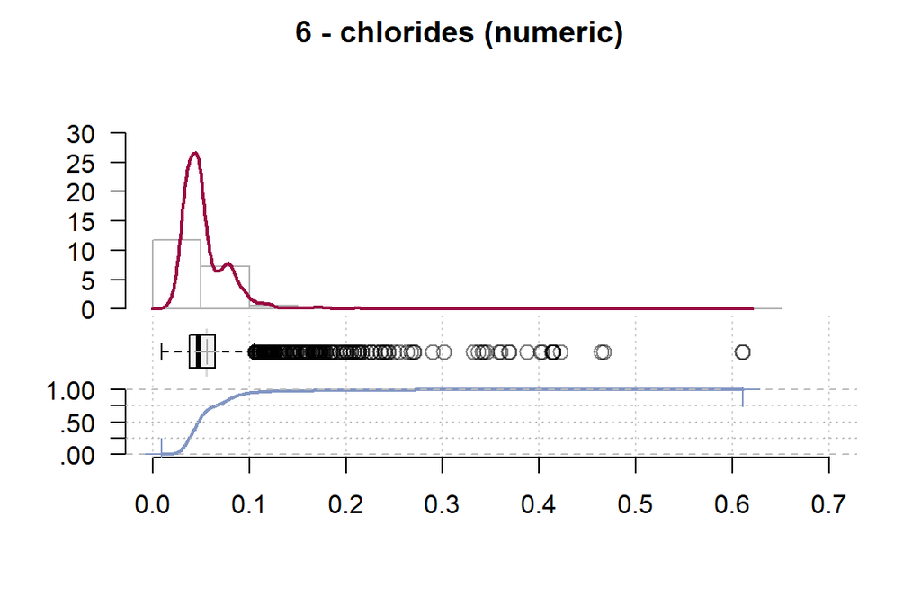

```
## ------------------------------------------------------------------------------
## 7 - free.sulfur.dioxide (numeric)
##
##   length       n    NAs  unique     0s   mean  meanCI'
##    6'497   6'497      0     135      0  30.53   30.09
##           100.0%   0.0%           0.0%          30.96
##
##      .05     .10    .25  median    .75    .90     .95
##     6.00    9.00  17.00   29.00  41.00  54.00   61.00
##
##    range      sd  vcoef     mad    IQR   skew    kurt
##   288.00   17.75   0.58   17.79  24.00   1.22    7.90
##
## lowest : 1.0 (3), 2.0 (2), 3.0 (59), 4.0 (52), 5.0 (129)
## highest: 128.0, 131.0, 138.5, 146.5, 289.0
##
## ' 95%-CI (classic)
```

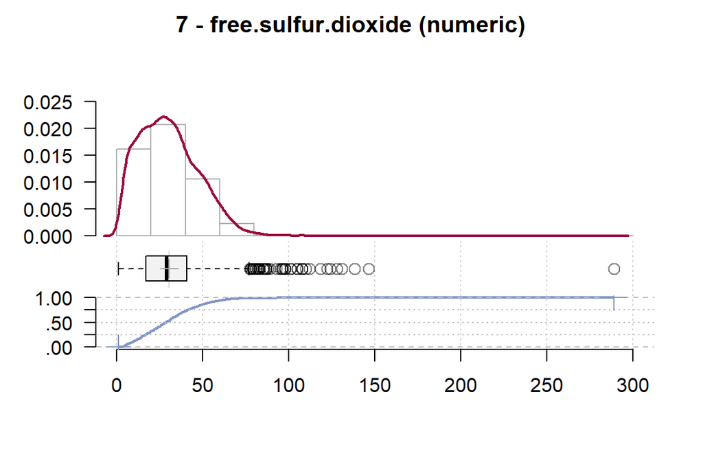

```
## ------------------------------------------------------------------------------
## 8 - total.sulfur.dioxide (numeric)
##
##   length       n    NAs  unique      0s    mean  meanCI'
##    6'497   6'497      0     276       0  115.74  114.37
##           100.0%   0.0%            0.0%          117.12
##
##      .05     .10    .25  median     .75     .90     .95
##    19.00   30.00  77.00  118.00  156.00  188.00  206.00
##
##    range      sd  vcoef     mad     IQR    skew    kurt
##   434.00   56.52   0.49   57.82   79.00   -0.00   -0.37
##
## lowest : 6.0 (3), 7.0 (4), 8.0 (14), 9.0 (15), 10.0 (28)
## highest: 307.5, 313.0, 344.0, 366.5, 440.0
##
## ' 95%-CI (classic)
```

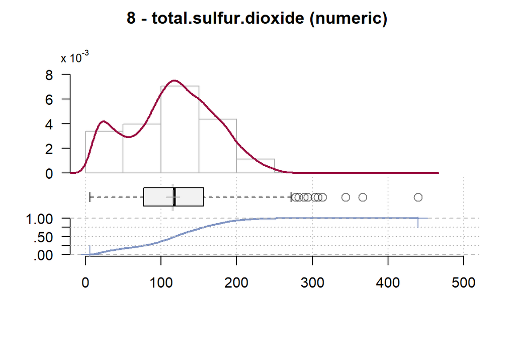

```
## ------------------------------------------------------------------------------
## 9 - density (numeric)
##
##     length         n       NAs    unique        0s      mean    meanCI'
##      6'497     6'497         0       998         0  0.994697  0.994624
##               100.0%      0.0%                0.0%            0.994770
##
##        .05       .10       .25    median       .75       .90       .95
##   0.989900  0.990670  0.992340  0.994890  0.996990  0.998400  0.999392
##
##      range        sd     vcoef       mad       IQR      skew      kurt
##   0.051870  0.002999  0.003015  0.003425  0.004650  0.503369  6.597106
##
## lowest : 0.98711, 0.98713, 0.98722, 0.9874, 0.98742 (2)
## highest: 1.00315 (3), 1.0032, 1.00369 (2), 1.0103 (2), 1.03898
##
## ' 95%-CI (classic)
```

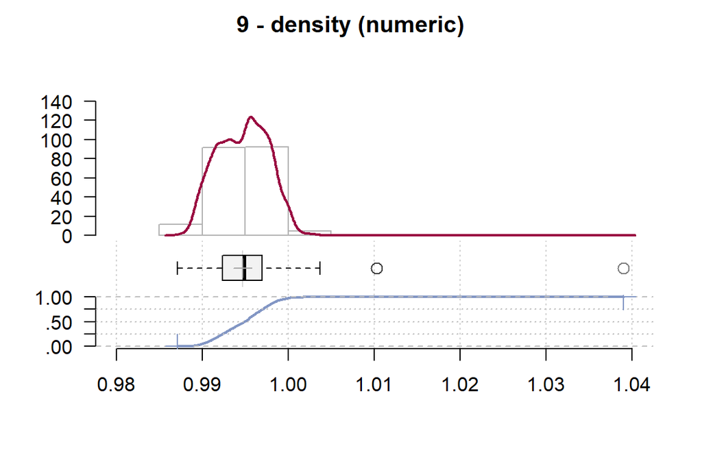

```
## ------------------------------------------------------------------------------
## 10 - pH (numeric)
##
##   length       n    NAs  unique    0s  mean  meanCI'
##    6'497   6'497      0     108     0  3.22    3.21
##           100.0%   0.0%          0.0%          3.22
##
##      .05     .10    .25  median   .75   .90     .95
##     2.97    3.02   3.11    3.21  3.32  3.42    3.50
##
##    range      sd  vcoef     mad   IQR  skew    kurt
##     1.29    0.16   0.05    0.16  0.21  0.39    0.37
##
## lowest : 2.72, 2.74 (2), 2.77, 2.79 (3), 2.8 (3)
## highest: 3.81, 3.82, 3.85, 3.9 (2), 4.01 (2)
##
## ' 95%-CI (classic)
```

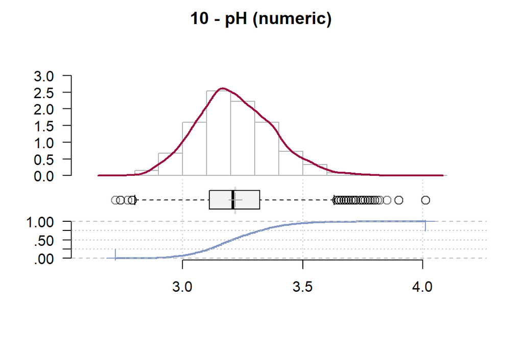

```
## ------------------------------------------------------------------------------
## 11 - sulphates (numeric)
##
##   length       n    NAs  unique    0s  mean  meanCI'
##    6'497   6'497      0     111     0  0.53    0.53
##           100.0%   0.0%          0.0%          0.53
##
##      .05     .10    .25  median   .75   .90     .95
##     0.35    0.37   0.43    0.51  0.60  0.72    0.79
##
##    range      sd  vcoef     mad   IQR  skew    kurt
##     1.78    0.15   0.28    0.12  0.17  1.80    8.64
##
## lowest : 0.22, 0.23, 0.25 (4), 0.26 (4), 0.27 (13)
## highest: 1.61, 1.62, 1.95 (2), 1.98, 2.0
##
## ' 95%-CI (classic)
```

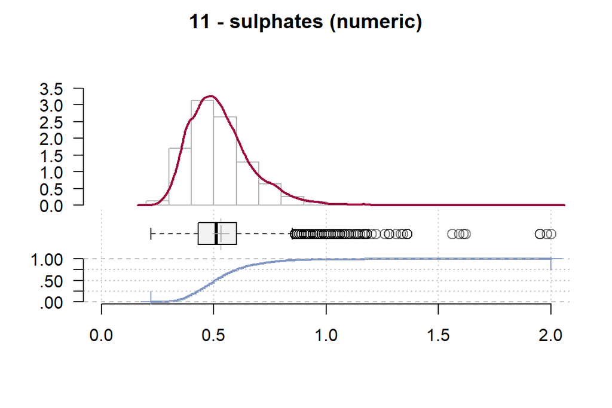

```
## ------------------------------------------------------------------------------
## 12 - alcohol (numeric)
##
##   length       n    NAs  unique     0s   mean  meanCI'
##    6'497   6'497      0     111      0  10.49   10.46
##           100.0%   0.0%           0.0%          10.52
##
##      .05     .10    .25  median    .75    .90     .95
##     9.00    9.10   9.50   10.30  11.30  12.30   12.70
##
##    range      sd  vcoef     mad    IQR   skew    kurt
##     6.90    1.19   0.11    1.33   1.80   0.57   -0.53
##
## lowest : 8.0 (2), 8.4 (5), 8.5 (10), 8.6 (23), 8.7 (80)
## highest: 13.9 (3), 14.0 (12), 14.05, 14.2, 14.9
##
## heap(?): remarkable frequency (5.6%) for the mode(s) (= 9.5)
##
## ' 95%-CI (classic)
```

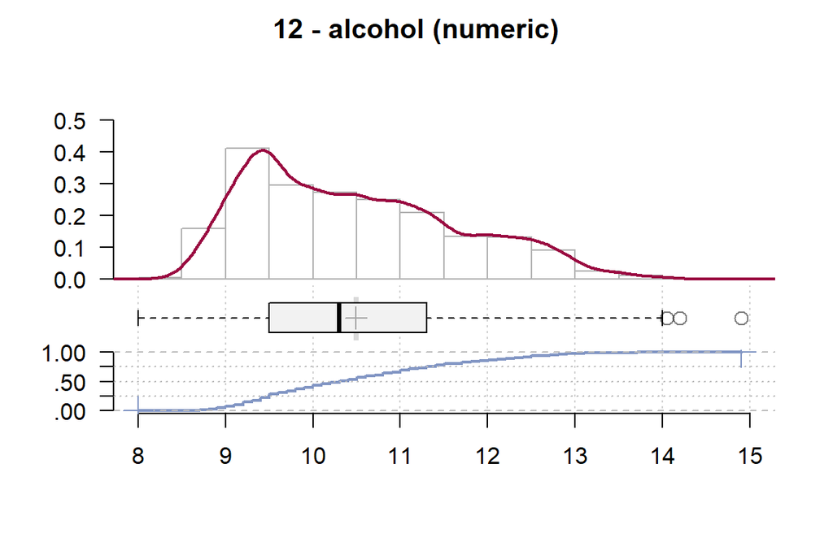

```
## ------------------------------------------------------------------------------
## 13 - quality (integer)
##
##   length       n    NAs  unique    0s  mean  meanCI'
##    6'497   6'497      0       7     0  5.82    5.80
##           100.0%   0.0%          0.0%          5.84
##
##      .05     .10    .25  median   .75   .90     .95
##     5.00    5.00   5.00    6.00  6.00  7.00    7.00
##
##    range      sd  vcoef     mad   IQR  skew    kurt
##     6.00    0.87   0.15    1.48  1.00  0.19    0.23
##
##
##    value   freq   perc  cumfreq  cumperc
## 1      3     30   0.5%       30     0.5%
## 2      4    216   3.3%      246     3.8%
## 3      5  2'138  32.9%    2'384    36.7%
## 4      6  2'836  43.7%    5'220    80.3%
## 5      7  1'079  16.6%    6'299    97.0%
## 6      8    193   3.0%    6'492    99.9%
## 7      9      5   0.1%    6'497   100.0%
##
## ' 95%-CI (classic)
```

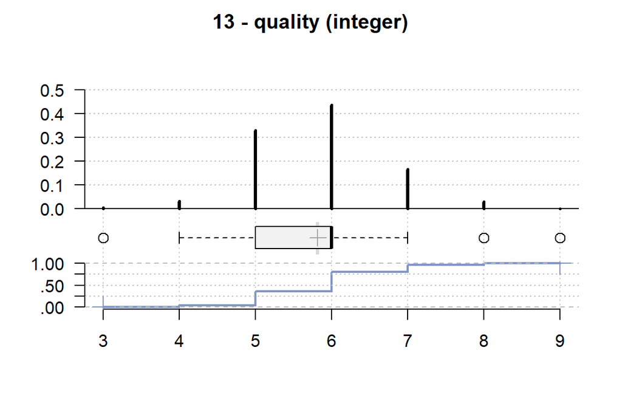

```
## ------------------------------------------------------------------------------
## 14 - quality_gr (ordered, factor)
##
##   length      n    NAs unique levels  dupes
##    6'497  6'497      0      3      3      y
##          100.0%   0.0%
##
##     level   freq   perc  cumfreq  cumperc
## 1     low    246   3.8%      246     3.8%
## 2  medium  4'974  76.6%    5'220    80.3%
## 3    high  1'277  19.7%    6'497   100.0%
```

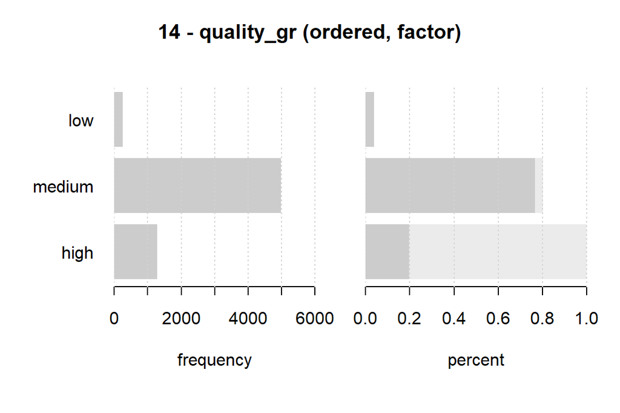

### **Tarpinis apibendrinimas**

Apibūdinkite duomenis, trumpai aprašykite iki šiol gautus rezultatus, svarbiausius pastebėjimus.

### Įvertinkite asimetrijos laipsnį

Įvertinkite kiekybinių kintamųjų asimetriją kiekybiškai.

**Techniniai reikalavimai**

Žemiau duotas užkomentuotas kodo fragmentas, kurį reikia atkomentuoti ir pataisyti, kad veiktų tinkamai.

Jei nesuprantate, ką viena ar kita kodo dalis daro, galite laikinai ją pašalinti ir patikrinti.

Techniniai reikalavimai kodui:

1. Analizuokite tik kiekybinius stulpelius.
2. Apskaičiuokite asimetrijos koeficientą.
3. Koeficientą suapvalinkite 2 skaitmenų po kablelio tikslumu.
4. Teisingai apskaičiuokite stulpelį, kurio reikšmės yra “taip” ir “ne”.
5. Eilutes išrikiuokite pagal asimetrijos koeficiento didumą mažėjimo tvarka.

*Preliminari* asimetrijos koef. interpretacija:  
0 – simetriška,  
daugiau už +1 – smarki dešinioji asimetrija,  
mažiau už -1 – smarki kairioji asimetrija.

```r
asimetr_koef <-
  wine %>%
  summarize(across(where(is.numeric),
    list("asimetrijos_koef" = DescTools::Skew))) %>%
  pivot_longer(
    everything(),
    names_pattern = "(.+?)_(.+)",
    names_to = c("kintamasis", ".value")
  ) %>%
  mutate(
    asimetrijos_koef = round(asimetrijos_koef, digits = 2),
    smarki_asimetrija = if_else(abs(asimetrijos_koef) > 1,
      true = "taip", false = "ne")
  ) %>%
  arrange(desc(asimetrijos_koef))
asimetr_koef
```

| kintamasis | asimetrijos_koef | smarki_asimetrija |
| --- | --- | --- |
| chlorides | 5.40 | taip |
| sulphates | 1.80 | taip |
| fixed.acidity | 1.72 | taip |
| volatile.acidity | 1.49 | taip |
| residual.sugar | 1.43 | taip |
| free.sulfur.dioxide | 1.22 | taip |
| alcohol | 0.57 | ne |
| density | 0.50 | ne |
| citric.acid | 0.47 | ne |
| pH | 0.39 | ne |

[output cut: 2 more lines]

```r
asimetr_koef <-
  wine %>%
  summarize(across(where(is.numeric),
    list("asimetrijos_koef" = DescTools::Skew))) %>%
  pivot_longer(
    everything(),
    names_pattern = "(.+?)_(.+)",
    names_to = c("kintamasis", ".value")
  ) %>%
  mutate(
    asimetrijos_koef = round(asimetrijos_koef, digits = 2),
    smarki_asimetrija = if_else(abs(asimetrijos_koef) < -1,
      true = "taip", false = "ne")
  ) %>%
  arrange(desc(asimetrijos_koef))
asimetr_koef
```

| kintamasis | asimetrijos_koef | smarki_asimetrija |
| --- | --- | --- |
| chlorides | 5.40 | ne |
| sulphates | 1.80 | ne |
| fixed.acidity | 1.72 | ne |
| volatile.acidity | 1.49 | ne |
| residual.sugar | 1.43 | ne |
| free.sulfur.dioxide | 1.22 | ne |
| alcohol | 0.57 | ne |
| density | 0.50 | ne |
| citric.acid | 0.47 | ne |
| pH | 0.39 | ne |

[output cut: 2 more lines]

Suskaičiuokite, keli kintamieji pasižymi smarkia asimetrija.

6 kintamieji pasižymi smarkia asimetrija

### Pertvarkykite lentelę: `wines_log`

Sukurkite duomenų lentelės kopiją (`wines_log`), kurioje smarkia dešiniąja asimetrija pasižymintys kintamieji būtų logaritmuoti. Pradinius kintamuosius, kurie buvo naudoti logaritmavimui, pašalinkite (pvz., jei lentelėje būtų kintamieji `svoris` ir `log_svoris`, tai `svoris` turėtų būti pašalintas). Kintamųjų skaičius lentelėje `wines_log` turi būti tiks pats kaip ir lentelėje `wines`.

```r
wines2 <- wine %>%
  select(chlorides, sulphates, fixed.acidity, volatile.acidity,
residual.sugar, free.sulfur.dioxide)
wines_logs <- log10(wines2)
```

```r
wines3 <-
  wine %>%
  select(alcohol, density, citric.acid, pH, quality, total.sulfur.dioxide)
wines3
```

| alcohol | density | citric.acid | pH | quality | total.sulfur.dioxide |
| --- | --- | --- | --- | --- | --- |
| 9.400000 | 0.997800 | 0.00 | 3.51 | 5 | 34.0 |
| 9.800000 | 0.996800 | 0.00 | 3.20 | 5 | 67.0 |
| 9.800000 | 0.997000 | 0.04 | 3.26 | 5 | 54.0 |
| 9.800000 | 0.998000 | 0.56 | 3.16 | 6 | 60.0 |
| 9.400000 | 0.997800 | 0.00 | 3.51 | 5 | 34.0 |
| 9.400000 | 0.997800 | 0.00 | 3.51 | 5 | 40.0 |
| 9.400000 | 0.996400 | 0.06 | 3.30 | 5 | 59.0 |
| 10.000000 | 0.994600 | 0.00 | 3.39 | 7 | 21.0 |
| 9.500000 | 0.996800 | 0.02 | 3.36 | 7 | 18.0 |
| 10.500000 | 0.997800 | 0.36 | 3.35 | 5 | 102.0 |

[output cut: 6487 more lines]

```r
wines_log <-
  bind_cols("log" = wines2, "non_log" = wines3)

remove(wines2, wines3)
```

```r
glimpse(wines_log)
```

```
## Rows: 6,497
## Columns: 12
## $ chlorides            <dbl> 0.076, 0.098, 0.092, 0.075, 0.076, 0.075, 0.069, …
## $ sulphates            <dbl> 0.56, 0.68, 0.65, 0.58, 0.56, 0.56, 0.46, 0.47, 0…
## $ fixed.acidity        <dbl> 7.4, 7.8, 7.8, 11.2, 7.4, 7.4, 7.9, 7.3, 7.8, 7.5…
## $ volatile.acidity     <dbl> 0.700, 0.880, 0.760, 0.280, 0.700, 0.660, 0.600, …
## $ residual.sugar       <dbl> 1.9, 2.6, 2.3, 1.9, 1.9, 1.8, 1.6, 1.2, 2.0, 6.1,…
## $ free.sulfur.dioxide  <dbl> 11, 25, 15, 17, 11, 13, 15, 15, 9, 17, 15, 17, 16…
## $ alcohol              <dbl> 9.4, 9.8, 9.8, 9.8, 9.4, 9.4, 9.4, 10.0, 9.5, 10.…
## $ density              <dbl> 0.9978, 0.9968, 0.9970, 0.9980, 0.9978, 0.9978, 0…
## $ citric.acid          <dbl> 0.00, 0.00, 0.04, 0.56, 0.00, 0.00, 0.06, 0.00, 0…
## $ pH                   <dbl> 3.51, 3.20, 3.26, 3.16, 3.51, 3.51, 3.30, 3.39, 3…
## $ quality              <int> 5, 5, 5, 6, 5, 5, 5, 7, 7, 5, 5, 5, 5, 5, 5, 5, 7…
## $ total.sulfur.dioxide <dbl> 34, 67, 54, 60, 34, 40, 59, 21, 18, 102, 65, 102,…
```

### Sudarykite koreliacijos koeficientų matricą

Sudarykite koreliacijos koeficientų matricą ir kelis svarbiausius pastebėjimus ir ryškiausius dalykus aprašykite.

```r
cor(wines_log)
```

```
##                        chlorides    sulphates fixed.acidity volatile.acidity
## chlorides             1.00000000  0.395593307    0.29819477       0.37712428
## sulphates             0.39559331  1.000000000    0.29956774       0.22598368
## fixed.acidity         0.29819477  0.299567744    1.00000000       0.21900826
## volatile.acidity      0.37712428  0.225983680    0.21900826       1.00000000
## residual.sugar       -0.12894050 -0.185927405   -0.11198128      -0.19601117
## free.sulfur.dioxide  -0.19504479 -0.188457249   -0.28273543      -0.35255731
## alcohol              -0.25691558 -0.003029195   -0.09545152      -0.03764039
## density               0.36261466  0.259478495    0.45890998       0.27129565
## citric.acid           0.03899801  0.056197300    0.32443573      -0.37798132
## pH                    0.04470798  0.192123407   -0.25270047       0.26145440
## quality              -0.20066550  0.038485446   -0.07674321      -0.26569948
## total.sulfur.dioxide -0.27963045 -0.275726820   -0.32905390      -0.41447619
##                      residual.sugar free.sulfur.dioxide      alcohol
## chlorides               -0.12894050         -0.19504479 -0.256915580
## sulphates               -0.18592741         -0.18845725 -0.003029195
## fixed.acidity           -0.11198128         -0.28273543 -0.095451523
## volatile.acidity        -0.19601117         -0.35255731 -0.037640386
## residual.sugar           1.00000000          0.40287064 -0.359414771
## free.sulfur.dioxide      0.40287064          1.00000000 -0.179838435
## alcohol                 -0.35941477         -0.17983843  1.000000000
## density                  0.55251695          0.02571684 -0.686745422
## citric.acid              0.14245123          0.13312581 -0.010493492
## pH                      -0.26731984         -0.14585390  0.121248467
## quality                 -0.03698048          0.05546306  0.444318520
## total.sulfur.dioxide     0.49548159          0.72093408 -0.265739639
##                          density citric.acid          pH     quality
## chlorides             0.36261466  0.03899801  0.04470798 -0.20066550
## sulphates             0.25947850  0.05619730  0.19212341  0.03848545
## fixed.acidity         0.45890998  0.32443573 -0.25270047 -0.07674321
## volatile.acidity      0.27129565 -0.37798132  0.26145440 -0.26569948
## residual.sugar        0.55251695  0.14245123 -0.26731984 -0.03698048
## free.sulfur.dioxide   0.02571684  0.13312581 -0.14585390  0.05546306
## alcohol              -0.68674542 -0.01049349  0.12124847  0.44431852
## density               1.00000000  0.09615393  0.01168608 -0.30585791
## citric.acid           0.09615393  1.00000000 -0.32980819  0.08553172
## pH                    0.01168608 -0.32980819  1.00000000  0.01950570
## quality              -0.30585791  0.08553172  0.01950570  1.00000000
## total.sulfur.dioxide  0.03239451  0.19524198 -0.23841310 -0.04138545
##                      total.sulfur.dioxide
## chlorides                     -0.27963045
## sulphates                     -0.27572682
## fixed.acidity                 -0.32905390
## volatile.acidity              -0.41447619
## residual.sugar                 0.49548159
## free.sulfur.dioxide            0.72093408
## alcohol                       -0.26573964
## density                        0.03239451
## citric.acid                    0.19524198
## pH                            -0.23841310
## quality                       -0.04138545
## total.sulfur.dioxide           1.00000000
```

### Atlikite PCA

Korektiškai sudarykite PCA modelį. Jei manote, kad duomenyse yra išskirčių, kurios gali paveikti PCA rezultatus, kelis taškus galite pašalinti prieš sudarydami modelį. Taip pat pagalvokite, kas labiau tinka: logaritmuoti ar asimetriški kintamieji.

Tada atlikite bazinę modelio diagnostiką (tinkamumo vertinimą).

Galiausiai pasirinkę reikiamą grafiką įvertinkite, kurie kintamieji, tikėtina, labiausiai susiję su vyno tipu (raudonasis ar baltasis). Naudokite tik dvi pirmąsias pagrindines komponentes (PC).

Po kiekvienu grafiku rezultatus glaustai aprašykite. Pateikite paaiškinimus, kodėl manote vienaip ar kitaip.

```r
wines_numeric <- wines_log %>% select(where(is.numeric))

pca_modelis_1 <- prcomp(wines_numeric, center = TRUE, scale = TRUE)
pca_modelis_1
```

```
## Standard deviations (1, .., p=12):
##  [1] 1.7440032 1.6278372 1.2812130 1.0337433 0.9167881 0.8126495 0.7508838
##  [8] 0.7183195 0.6770320 0.5468207 0.4770613 0.1810667
##
## Rotation (n x k) = (12 x 12):
##                              PC1        PC2         PC3         PC4
## chlorides            -0.31344994  0.2697701 -0.04676921  0.16529004
## sulphates            -0.29985192  0.1196342 -0.16869128  0.58801992
## fixed.acidity        -0.25692873  0.2618431 -0.46748619 -0.14396377
## volatile.acidity     -0.39493118  0.1051983  0.27968932 -0.08005785
## residual.sugar        0.31890519  0.3425850  0.07550170  0.11245623
## free.sulfur.dioxide   0.42269137  0.1111788  0.09899801  0.30330631
## alcohol              -0.05892408 -0.4927275 -0.21293142  0.08003179
## density              -0.09243753  0.5549205  0.05156338  0.15057853
## citric.acid           0.14646061  0.1440935 -0.58807557  0.05551036
## pH                   -0.20806957 -0.1529219  0.40678741  0.47147768
## quality               0.08747571 -0.2966009 -0.29583773  0.47243936
## total.sulfur.dioxide  0.47441968  0.1439475  0.10128143  0.13223199
##                               PC5         PC6         PC7          PC8
## chlorides            -0.393896604  0.42544212 -0.47329609  0.375531558
## sulphates            -0.193245549  0.02014082  0.17023612 -0.592220645
## fixed.acidity         0.165362611 -0.03003708  0.39343530  0.001155415
## volatile.acidity      0.147774077  0.38266373  0.44511080  0.310077574
## residual.sugar        0.507921181  0.06331719 -0.09576310  0.081944829
## free.sulfur.dioxide  -0.248451958  0.28318017  0.36271398  0.120097626
## alcohol               0.116023190  0.16947538  0.33890566  0.226040866
## density               0.330357303 -0.15455292  0.01328572  0.042943625
## citric.acid          -0.234621394 -0.36224839  0.04769762  0.444962196
## pH                   -0.001457502 -0.56089714  0.07932113  0.362281828
## quality               0.459129140  0.27788835 -0.27317740  0.093046206
## total.sulfur.dioxide -0.223966811  0.10676882  0.23481304  0.011279269
##                              PC9        PC10         PC11          PC12
## chlorides            -0.04404975  0.23887258  0.193398397  0.0432778637
## sulphates            -0.29740108 -0.08546912 -0.047219109  0.0781995574
## fixed.acidity         0.42416913  0.27243245  0.276932032  0.3350925313
## volatile.acidity     -0.12323319 -0.49394624 -0.140799120  0.0824207437
## residual.sugar       -0.48802361  0.20717448 -0.005144195  0.4512148285
## free.sulfur.dioxide   0.30139683  0.30344826 -0.486158400  0.0009050256
## alcohol              -0.41706026  0.41605905  0.191289020 -0.3320120790
## density               0.07108094  0.07681483  0.003324491 -0.7156665472
## citric.acid          -0.24623265 -0.33035538 -0.229276179 -0.0013466535
## pH                    0.13666158  0.11240888  0.139083153  0.2067626762
## quality               0.35664731 -0.30782956  0.018082206 -0.0082880344
## total.sulfur.dioxide  0.00181386 -0.29478016  0.720162498 -0.0640632122
```

```r
get_eigenvalue(pca_modelis_1) %>%
  round(1)
```

|  | eigenvalue | variance.percent | cumulative.variance.percent |
| --- | --- | --- | --- |
| Dim.1 | 3.0 | 25.3 | 25.3 |
| Dim.2 | 2.6 | 22.1 | 47.4 |
| Dim.3 | 1.6 | 13.7 | 61.1 |
| Dim.4 | 1.1 | 8.9 | 70.0 |
| Dim.5 | 0.8 | 7.0 | 77.0 |
| Dim.6 | 0.7 | 5.5 | 82.5 |
| Dim.7 | 0.6 | 4.7 | 87.2 |
| Dim.8 | 0.5 | 4.3 | 91.5 |
| Dim.9 | 0.5 | 3.8 | 95.3 |
| Dim.10 | 0.3 | 2.5 | 97.8 |

[output cut: 2 more lines]

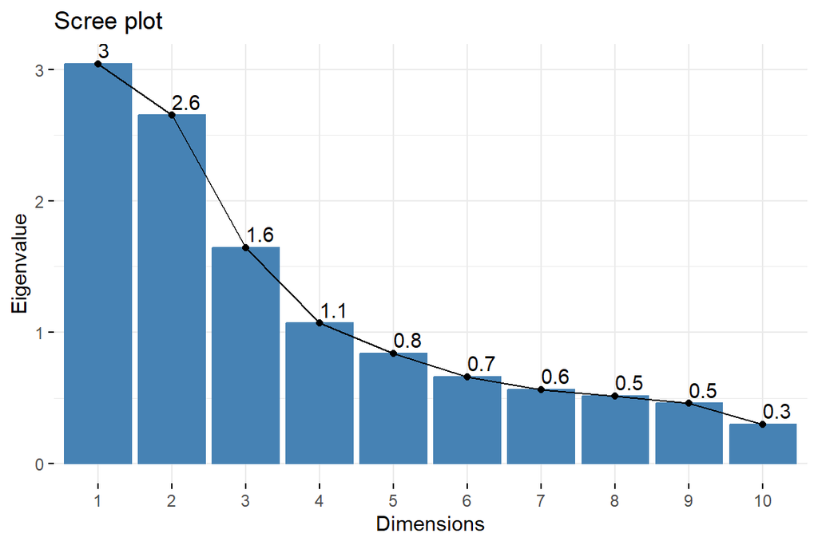

```r
fviz_screeplot(pca_modelis_1, addlabels = TRUE, choice = "eigenvalue")
```

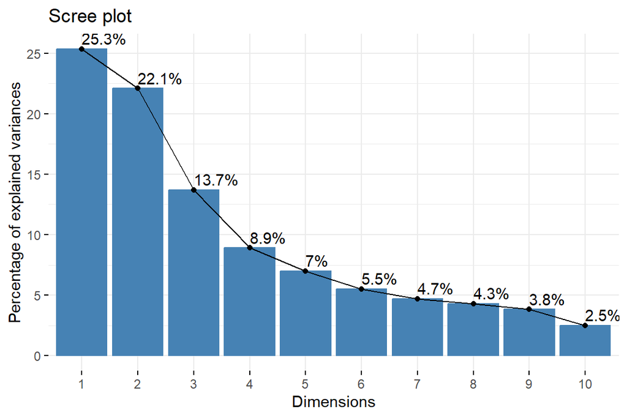

```r
fviz_screeplot(pca_modelis_1, addlabels = TRUE, choice = "variance")
```

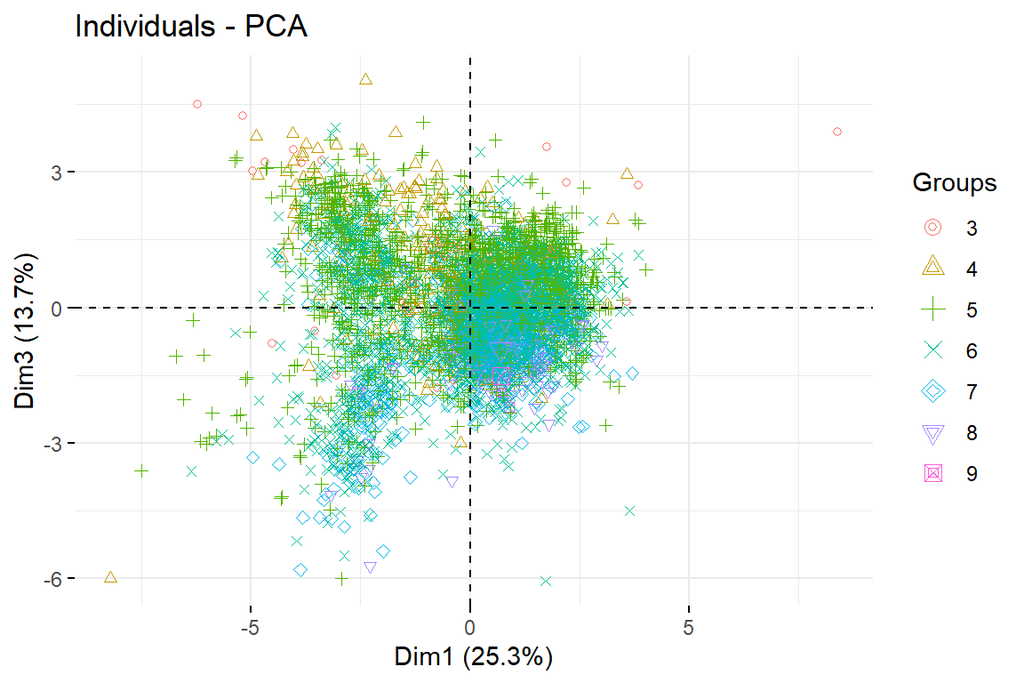

```r
fviz_pca_ind(
  pca_modelis_1,
  axes = c(1, 3),
  geom = "point",
  habillage = wines_log$quality
)
```

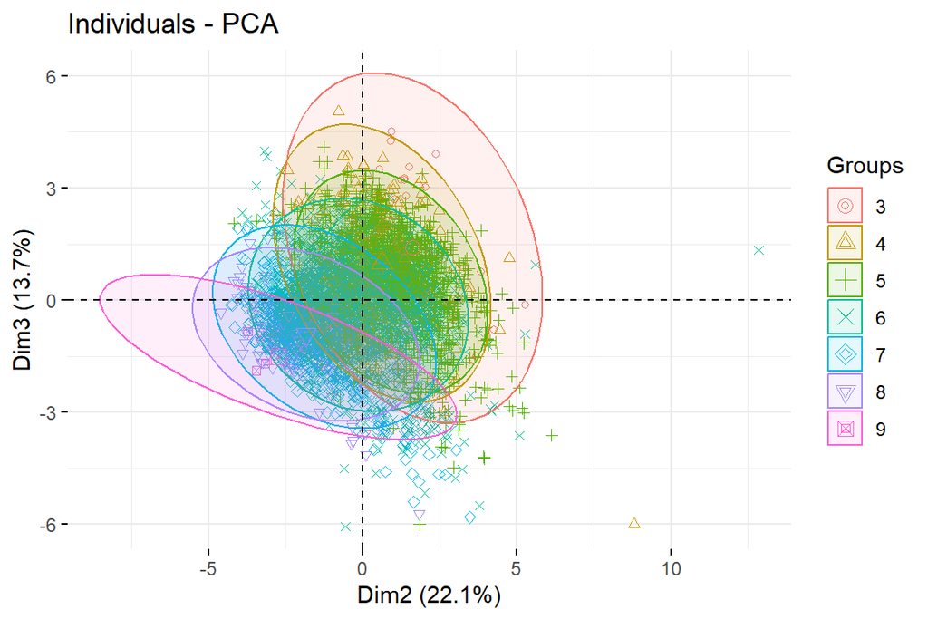

```r
fviz_pca_ind(
  pca_modelis_1,
  axes = c(2, 3),
  geom = "point",
  habillage = wines_log$quality,
  addEllipses   = TRUE
)
```

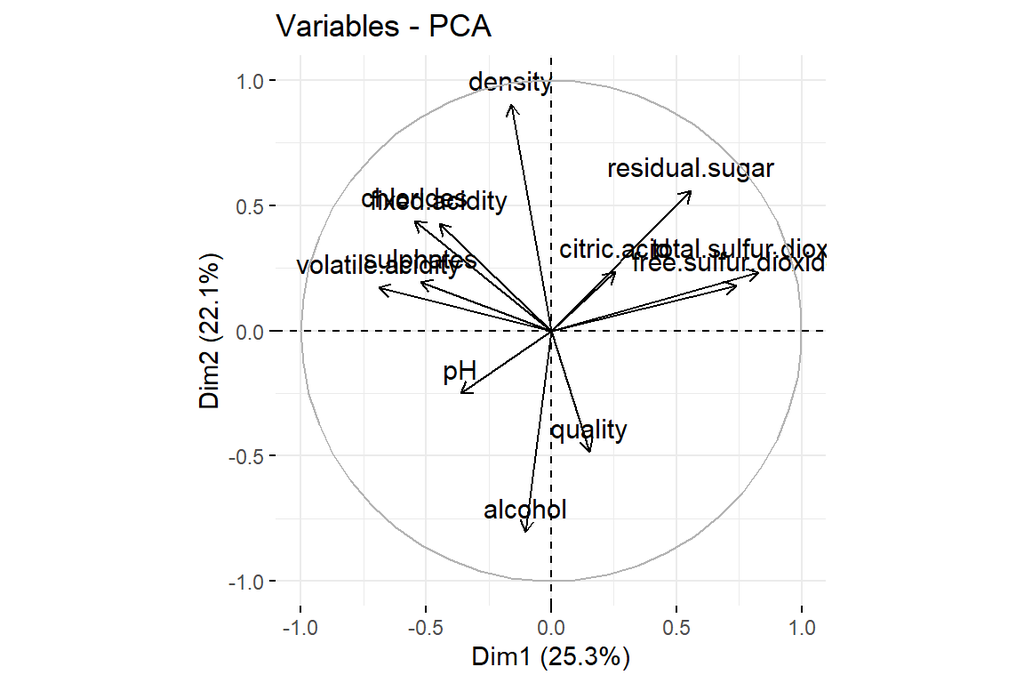

```r
fviz_pca_var(pca_modelis_1)
```

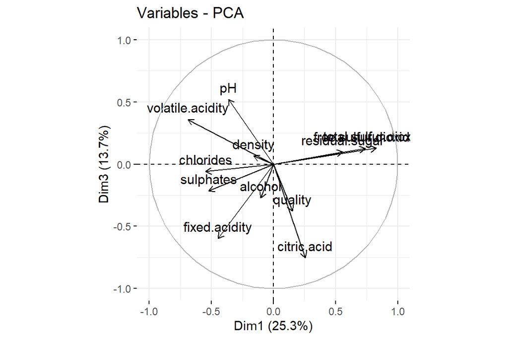

```r
fviz_pca_var(pca_modelis_1, axes = c(1, 3))
```

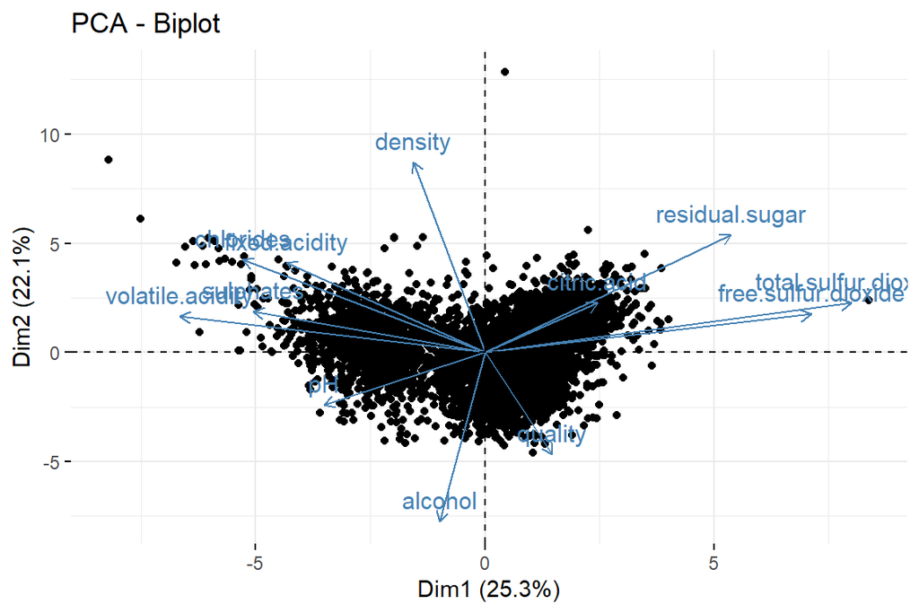

```r
fviz_pca_biplot(pca_modelis_1, label = "var", geom.ind = "point")
```

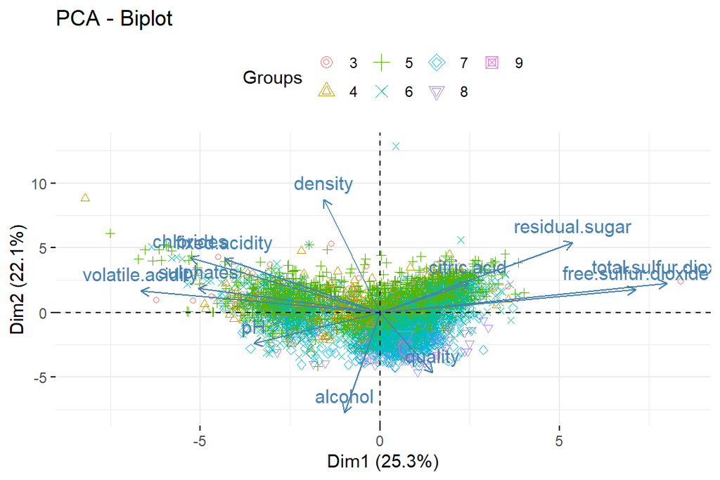

```r
fviz_pca_biplot(
  pca_modelis_1,
  geom.ind  = "point",
  habillage = wines_log$quality,
  legend    = "top"
)
```

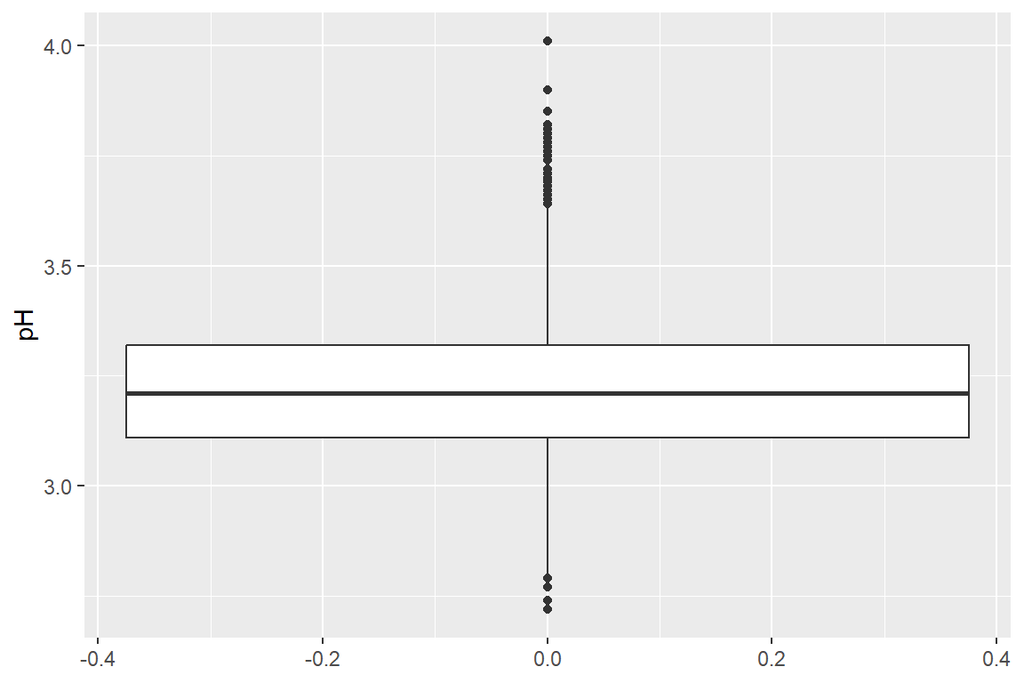

```r
ggplot(wines_log, aes(y = pH, fill = quality)) +
  geom_boxplot()
```

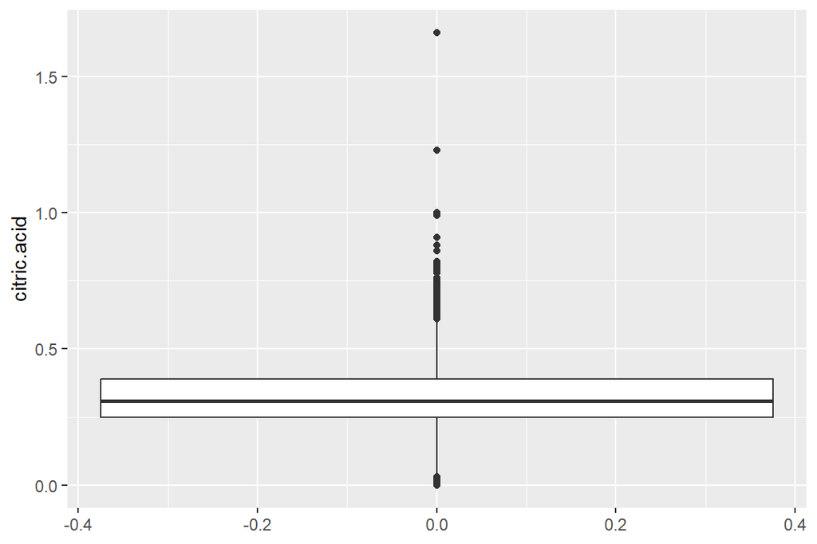

```r
ggplot(wines_log, aes(y = citric.acid, fill = quality)) +
  geom_boxplot()
```

```r
theme_axes_as_arrows <- function(variables, linewidth = 1, hjust = 1) {
  arrow_params <- arrow(length = unit(0.5, "lines"))
  theme(
    axis.title.x = element_text(hjust = hjust),
    axis.title.y = element_text(hjust = hjust),
    axis.line = element_line(arrow = arrow_params, linewidth = linewidth)
  )
}
```

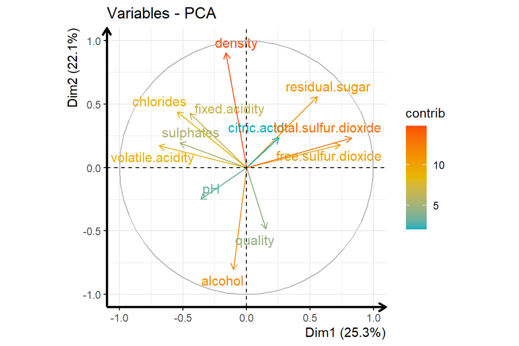

```r
fviz_pca_var(
  pca_modelis_1,
  axes = c(1, 2),
  col.var = "contrib",
  gradient.cols = c("#00AFBB", "#E7B800", "#FC4E07"),
  repel = TRUE
) +
  theme_axes_as_arrows()
```

## Logaritmuotos reikšmės

Didžiausią įtaką daro tankis g/cm^3 (angl. density), taip pat didelę įtaką daro alkoholio (angl. alcohol) bei totalus sieros dioksido kiekis (angl. total.sulfur.dioxide).

## Sprendimai (2). Tipas vs. kokybė

Naudodami vyno tipus ir kokybės grupes, įvertinkite, ar yra ryšys tarp šių kintamųjų. Laikykite, kad imtis yra atsitiktinė.

1. nubraižykite mozaikinę diagramą naudodami `ggplot2`.

```r
glimpse(wine)
```

```
## Rows: 6,497
## Columns: 14
## $ wine_type            <chr> "Red", "Red", "Red", "Red", "Red", "Red", "Red", …
## $ fixed.acidity        <dbl> 7.4, 7.8, 7.8, 11.2, 7.4, 7.4, 7.9, 7.3, 7.8, 7.5…
## $ volatile.acidity     <dbl> 0.700, 0.880, 0.760, 0.280, 0.700, 0.660, 0.600, …
## $ citric.acid          <dbl> 0.00, 0.00, 0.04, 0.56, 0.00, 0.00, 0.06, 0.00, 0…
## $ residual.sugar       <dbl> 1.9, 2.6, 2.3, 1.9, 1.9, 1.8, 1.6, 1.2, 2.0, 6.1,…
## $ chlorides            <dbl> 0.076, 0.098, 0.092, 0.075, 0.076, 0.075, 0.069, …
## $ free.sulfur.dioxide  <dbl> 11, 25, 15, 17, 11, 13, 15, 15, 9, 17, 15, 17, 16…
## $ total.sulfur.dioxide <dbl> 34, 67, 54, 60, 34, 40, 59, 21, 18, 102, 65, 102,…
## $ density              <dbl> 0.9978, 0.9968, 0.9970, 0.9980, 0.9978, 0.9978, 0…
## $ pH                   <dbl> 3.51, 3.20, 3.26, 3.16, 3.51, 3.51, 3.30, 3.39, 3…
## $ sulphates            <dbl> 0.56, 0.68, 0.65, 0.58, 0.56, 0.56, 0.46, 0.47, 0…
## $ alcohol              <dbl> 9.4, 9.8, 9.8, 9.8, 9.4, 9.4, 9.4, 10.0, 9.5, 10.…
## $ quality              <int> 5, 5, 5, 6, 5, 5, 5, 7, 7, 5, 5, 5, 5, 5, 5, 5, 7…
## $ quality_gr           <ord> medium, medium, medium, medium, medium, medium, m…
```

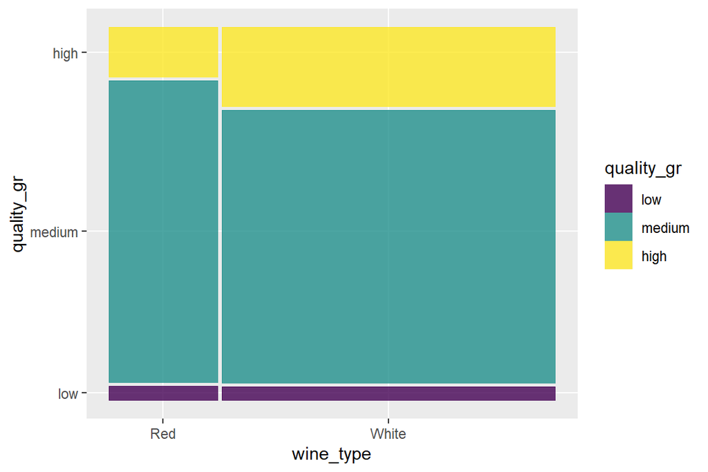

```r
ggplot(wine) +
  ggmosaic::geom_mosaic(aes(x = product(wine_type), fill = quality_gr))
```

2) įvertinkite statistinį reikšmingumą ir efekto dydį.

```r
summary(wine)
```

```
##   wine_type         fixed.acidity    volatile.acidity  citric.acid
##  Length:6497        Min.   : 3.800   Min.   :0.0800   Min.   :0.0000
##  Class :character   1st Qu.: 6.400   1st Qu.:0.2300   1st Qu.:0.2500
##  Mode  :character   Median : 7.000   Median :0.2900   Median :0.3100
##                     Mean   : 7.215   Mean   :0.3397   Mean   :0.3186
##                     3rd Qu.: 7.700   3rd Qu.:0.4000   3rd Qu.:0.3900
##                     Max.   :15.900   Max.   :1.5800   Max.   :1.6600
##  residual.sugar     chlorides       free.sulfur.dioxide total.sulfur.dioxide
##  Min.   : 0.600   Min.   :0.00900   Min.   :  1.00      Min.   :  6.0
##  1st Qu.: 1.800   1st Qu.:0.03800   1st Qu.: 17.00      1st Qu.: 77.0
##  Median : 3.000   Median :0.04700   Median : 29.00      Median :118.0
##  Mean   : 5.443   Mean   :0.05603   Mean   : 30.53      Mean   :115.7
##  3rd Qu.: 8.100   3rd Qu.:0.06500   3rd Qu.: 41.00      3rd Qu.:156.0
##  Max.   :65.800   Max.   :0.61100   Max.   :289.00      Max.   :440.0
##     density             pH          sulphates         alcohol
##  Min.   :0.9871   Min.   :2.720   Min.   :0.2200   Min.   : 8.00
##  1st Qu.:0.9923   1st Qu.:3.110   1st Qu.:0.4300   1st Qu.: 9.50
##  Median :0.9949   Median :3.210   Median :0.5100   Median :10.30
##  Mean   :0.9947   Mean   :3.219   Mean   :0.5313   Mean   :10.49
##  3rd Qu.:0.9970   3rd Qu.:3.320   3rd Qu.:0.6000   3rd Qu.:11.30
##  Max.   :1.0390   Max.   :4.010   Max.   :2.0000   Max.   :14.90
##     quality       quality_gr
##  Min.   :3.000   low   : 246
##  1st Qu.:5.000   medium:4974
##  Median :6.000   high  :1277
##  Mean   :5.818
##  3rd Qu.:6.000
##  Max.   :9.000
```

3. rezultatus trumpai, bet korektiškai aprašykite.

## Sprendimai (3). Klausimai apie duomenis

Išsikelkite 4 klausimus apie duomenis ir pateikite grafikus, kurie skirti atsakyti į tuos klausimus. Paklaidų skaičiuoti ir stat. hipotezių tikrinti nereikia. Tačiau jei reikia, galite naudoti aprašomąsias statistikas, kad patikslintumėte tai, ką matote grafike. Rezultatus pakomentuokite.

Techniniai reikalavimai:

1. Grafikus braižyti naudojant `ggplot2`.
2. Turi būti tokie grafikai:
   - grafikas 1 nominaliajam kintamajam.
   - grafikas 1 tolydžiajam kintamajam.
   - sklaidos diagrama.
   - grafikas kintamųjų porai kiekybinis-kokybinis.
3. Pakeisti grafikų temą: visi analizės grafikai turėtų naudoti tą pačią temą.
4. Tinkamai aprašyti grafikų ašis.
5. Grafikai turi būti tvarkingi, tikslūs ir aiškūs.

Žemiau pateikta šios užduoties atlikimui skirta forma.

### Klausimai

**Klausimas 1:** Kokios kokybės vyno yra daugiausiai? **Grafikas:**

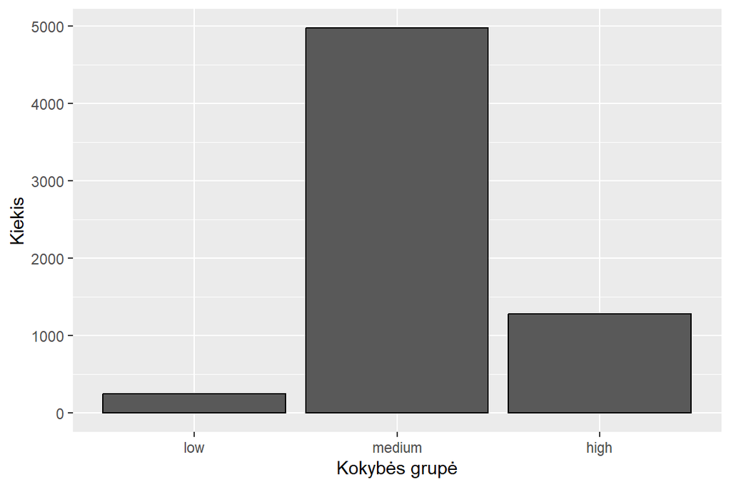

```r
ggplot(wine, aes(quality_gr)) +
  geom_bar(bins = 6, color = "black") +
  theme_grey() +
  xlab("Kokybės grupė") + ylab("Kiekis")
```

**Rezultatai:** Vidutinės koybės vyno yra daugiausiai.

**Klausimas 2:** Kokia yra vynų pH mediana? **Grafikas:**

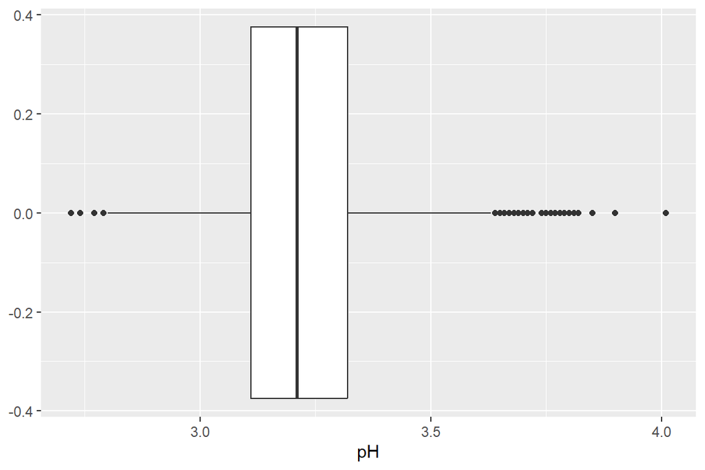

```r
ggplot(wine, aes(pH)) +
  geom_boxplot() +
  theme_grey() +
  xlab("pH")
```

**Rezultatai:** Vynų pH mediana yra apie 3,20.

**Klausimas 3:** Kaip priklauso pH vertė nuo citrinos rūgšties? **Grafikas:**

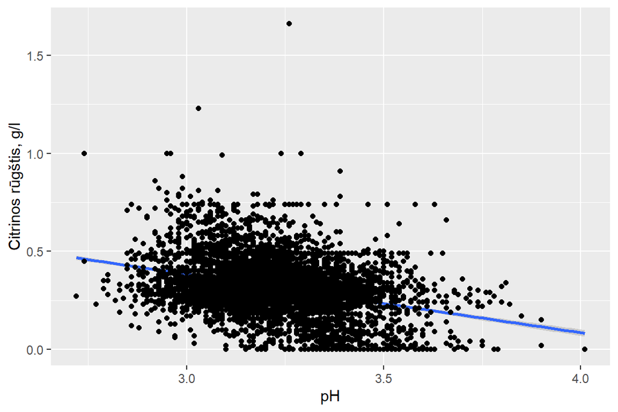

```r
ggplot(wine, aes(pH, citric.acid)) +
  geom_smooth(method = "lm", formula = y ~ x) +
  geom_point() +
  theme_grey() +
  xlab("pH") + ylab("Citrinos rūgštis, g/l")
```

**Rezultatai:** Kuo mažiau citrinos rūgšties, tuo didesnis pH. Idėjau ir regresijos tiesę, kad tai įrodyti - tiesė leidžiasi reiškias r koeficientas neigiamas, koreliacija neigiama.

**Klausimas 4:** Kokios kokybės vynas yra rūgščiausias? **Grafikas:**

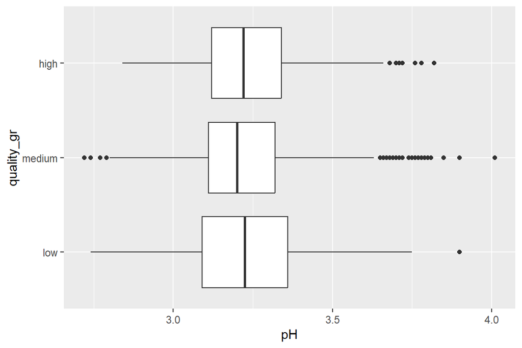

```r
ggplot(wine, aes(pH, quality_gr)) +
  geom_boxplot() +
  theme_grey()
```

# Užduotis 3 - Nedaryti

Rekomenduojama sprendimo trukmė: 40-60 min.

## Uždavinio sąlyga

Labai dažna užduotis atliekant duomenų analizę yra susirasti reikiamos analizės programos kodą internete arba gauti panašų kodą iš kolegos ir pagal savo duomenis poreikius jį modifikuoti taip, kad išspręstumėte savo klausimą/uždavinį. Ši užduotis kaip tik ir tikrins šį jūsų sugebėjimą.

**Uždavinio sąlyga**

**Pastaba:** šios užduoties sprendimo metu skaičiavimams skirto bloko apskritai *nelieskite*.

1. *Paketai.* Įsitikinkite, kad užkrovėte paketą, kuris su savimi kartu užkrauna `ggplot2`, `dplyr` ir analogiškus įrankius. Tai atlikite „R Markdown“ dokumento `setup` bloke.
2. *Kontekstas:* Kolega jums davė žemiau pateiktą kodą kaip pavyzdį ir bylą su keliomis funkcijomis (aplanke `funkcijos`). Tačiau žemiau patektas kodas neveikia, nes „R“ neranda kitoje byloje esančios funkcijos “`ci_multinom()`”. Yra keli būdai, kaip užsikrauti tokias funkcijas:
   1. Galite nusikopijuoti reikiamos funkcijos kodą į šį dokumentą (`setup` bloką). Bet tokiu atveju, jei pradinėje byloje atliksite pakeitimus, tada nukopijuotas kodas ųiame dokumente pats nepasikeis, o tai nėra patogu. Tad už šį sprendimo būdą bus skiriama žymiai mažiau taškų (arba neskiriama visai).
   2. Visgi įprastai funkcijos užkraunamos tiesiai iš “R sript” bylos `setup` bloke naudojant specialiai tam skirtą funkciją. Sprendimą pasufleruos šis straipsnis: https://www.statology.org/source-function-in-r/

   *Užduotis:* Priverskite funkciją “`ci_multinom()`” veikti. Tada iš žemiau pateiktų kodo blokų pašalinkite `eval=FALSE`. Paleiskite visą kodą ir jums bus nubraižytas grafikas (t.y., visas likęs užduoties šios kodas ims veikti). Gali būti, reiks įsidiegti papildomų paketų: jei tokia situacija susiklostys, “R” praneš, jums tereiks perskaityti ir įvykdyti.
3. *Grafiko tobulinimas 1.* Kai grafikas jau bus nubraižytas, jį patobulinkite:
   - Tai atlikite grafiko braižymui skirtame bloke.
   1. Y ašies pavadinimas turi būti pakeistas į „Procentinė dalis“.
   2. Y ašies reikšmės turi būti procentai, pvz., 20%. Sprendimą pasufleruos šis atsakymas: https://stackoverflow.com/a/41098629/4783029
   3. Įsitikinkite, kad ir šio grafiko tema tokia pati kaip kitų jūsų projekto `ggplot2` grafikų, bet ne standartinė `ggplot2` tema. Jei reikia, pakeiskite grafiko temą.
   4. Pakeiskite spalvų paletę.
4. *Naudokite reikiamus duomenis.* Atliktas tyrimas, kurio metu tikimybiškai surinkta pingvinų imtis (duomenų aplanke yra pingvinų duomenys; sakykime, kad imtis yra atsisiktinė). Jums pateiktas tik vienas su tirtais pingvinais susijęs požymis:
   1. įsikelkite duomenis.
      - Kodą rašykite virš bloko, skirto duomenų suvedimui.
   2. sudarykite dažnių lentelę ir ją atspausdinkite.
      - Kodą rašykite virš bloko, skirto duomenų suvedimui.
   3. pakeiskite pavadinimams ir empiriniams dažniams skirtų kintamųjų reikšmes. Pavadinimų eiliškumas turi atitikti Dažnių eiliškumas
      - Tai atlikite bloke, skirtame duomenų suvedimui.
   4. laikydami, kad teoriškai *Chinstrap* pingvinai turėtų būti sutinkami dvigubai rečiau nei kitos rūšys, užrašykite teorinius santykius (kiekvienai grupei po vieną skaičių: tinka bet koks užrašymas, išreiškiantis reikiamas proporcijas).
      - Tai atlikite bloke, skirtame duomenų suvedimui.
5. *Grafiko tobulinimas 2.*
   - Tai atlikite grafiko braižymui skirtame bloke.
   1. Jei reikia, pakeiskite legendos poziciją. Pastaba: `theme()` įprastai turi būti pridedama gale po kitų `ggplot2` elementų.
   2. Pakeiskite X ašies pavadinimą taip, kad atitiktų tai, kas vaizduojama grafike (dabar šio pavadinimo nesimato). Šios ašies pavadinimas nėra “pingvinai”: reikia tikslesnio.

   Šioje užduotyje turi būti tik vienas grafikas.

## Sprendimas

```r
# Duomenų suvedimas
pavadinimai <- c("Geltona, lygus", "Geltona, rauksletas", "Zalia, lygus",
  "Zalia, rauksletas")
empir_dazniai <- c(701, 243, 204, 68)
teor_santykiai <- c(9, 3, 3, 1)
```

```r
# PI skaičiavimas ir pateikimas reikiama forma
teor_proporcijos <-
  (teor_santykiai / sum(teor_santykiai)) |>
  set_names(pavadinimai) |>
  enframe("group", "est")

ci <- ci_multinom(set_names(empir_dazniai, pavadinimai), method = "goodman")

rez_empir_teor <-
  bind_rows(
    "Empirinės proporcijos" = ci,
    "Teorinės proporcijos" = teor_proporcijos,
    .id = "tipas"
  )

# Vaizdavimas suapvalinus
rez_empir_teor |> mutate(across(where(is.numeric), round, digits = 2))
```

```r
# Grafikas
rez_empir_teor |>
  ggplot(aes(x = group, y = est, fill = tipas)) +
  geom_col(color = "black", position = "dodge") +
  geom_errorbar(
    aes(ymin = lwr.ci, ymax = upr.ci),
    position = position_dodge2(width = 0.5, padding = 0.5),
    linewidth = 1
  ) +
  ggpubr::fill_palette("simpsons") +
  labs(y = "est", x = "", fill = "") +
  theme(
    legend.position = c(0.80, 0.90),
    legend.background = element_rect(fill = NA)
  )
```

# Užduotis 4. Pasitikrinkite

Rekomenduojama sprendimo trukmė: 15 min.

Pasitikrinkite, ar neliko klaidų ir reikiamus punktus pažymėkite kaip atliktus:

1. Pasitikrinkite, ar neliko duomenų analizės klaidų.
2. Pasitikrinkite, ar programos kodas parašytas laikantis *Tidyverse* reikalavimų:
   - panaudokite `styler`
   - panaudokite `lintr` ir ištaisykite likusias klaidas
3. Įsitikinkite, kad nėra *Markdown* formatavimo klaidų
4. Įsitikinkite, kad HTML dokumente
   - nėra dokumento struktūros išdarkymų,
   - paveikslų dydžiai yra adekvatūs,
   - lentelės ir kiti elementai atrodo adekvatūs ir neišdarykyti,
   - apvalinimas yra *protingas*.
5. Peržvelkite dokumentą, ar neliko rašybos klaidų (pabraukti žodžiai).
6. Įsitikinkite, kad visi pakeitimai išsaugoti naudojant *Git*.

**Užduoties progreso pildyo pavyzdys**

- Dar neatliktas punktas `[ ]`
- Jau atliktas punktas `[x]`